# Limits Day 1

Luke Bordonaro

## Let's start with functions

We're all familiar with functions. A function $f(x)$ takes in a number $x$ and gives a number out $f(x)$. We can plot these numbers to form a graph of $f(x)$

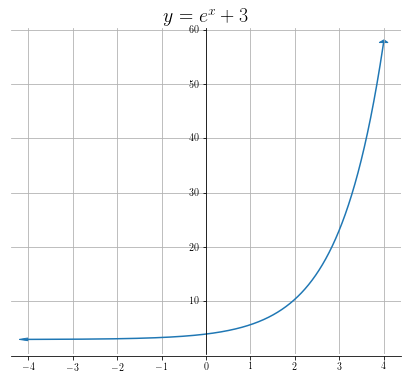

```python
#hideme

import math

def f(x):
    return (np.exp(x) + 3)

def makeArrowY(ax,pos,function,direction):
    delta = 0.0001 if direction >= 0 else -0.01
    ax.arrow(pos,function(pos),delta,function(pos+delta)-function(pos),head_width=0.2,head_length=0.5, color="#1f77b4")

def makeArrowX(ax,pos,function,direction):
    delta = 0.0001 if direction >= 0 else -0.01
    ax.arrow(pos,function(pos),delta,function(pos+delta)-function(pos),head_width=0.5,head_length=0.2, color="#1f77b4")


fig = plt.figure(figsize=(7, 6))
ax = fig.add_subplot(111)
ax.set_title("$y = e^x + 3$", fontsize=20)

xp = np.arange(-4, 4, 0.001)
yp = f(xp)
ax.plot(xp, yp)
#ax.yaxis.set_major_locator(ticker.MultipleLocator(1))

makeArrowX(ax, -4, f, -1)
makeArrowY(ax, 4, f, 1)


ax.grid(True)

ax.spines['left'].set_position('zero')
ax.spines['right'].set_color('none')
ax.spines['bottom'].set_position('zero')
ax.spines['top'].set_color('none')
ax.xaxis.set_ticks_position('bottom')
ax.yaxis.set_ticks_position('left')
```

What is the domain of this function?

## Let's start with functions

Unfortunately, not every function has a complete domain. Consider the function

\begin{equation} f(x) = \frac{(x^2 - 1)}{(x-1)} \end{equation}

What is its domain?

$\mathcal{D}\left(f(x)\right) =$ all numbers that are not $1$.

But what's happening at $f(1)$?

## Let's start with functions

\begin{equation} f(x) = \frac{(x^2 - 1)}{(x-1)} \end{equation}\begin{equation} f(1) = \frac{(1 - 1)}{(1 - 1)} = \frac{0}{0} \end{equation}

What is $\frac{0}{0}$???

## A graphical representation

Here is what the graph of $f(x)$ looks like.

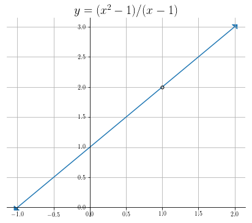

```python
#hideme

import math

def f(x):
    return (x**2 - 1)/(x - 1)

def makeArrowY(ax,pos,function,direction):
    delta = 0.0001 if direction >= 0 else -0.01
    ax.arrow(pos,function(pos),delta,function(pos+delta)-function(pos),head_width=0.2,head_length=0.5, color="#1f77b4")

def makeArrowX(ax,pos,function,direction):
    delta = 0.0001 if direction >= 0 else -0.01
    ax.arrow(pos,function(pos),delta,function(pos+delta)-function(pos),head_width=0.1,head_length=0.05, color="#1f77b4")


fig = plt.figure(figsize=(7, 6))
ax = fig.add_subplot(111)
ax.set_title("$y = (x^2 - 1)/(x-1)$", fontsize=20)

xleft = np.arange(-1, 0.99, 0.001)
xright = np.arange(1.01, 2, 0.001)
yright = f(xright)
yleft = f(xleft)
ax.plot(xleft, yleft)
ax.plot(xright, yright, color="#1f77b4")
#ax.yaxis.set_major_locator(ticker.MultipleLocator(1))

ax.plot(1, 2, marker='o', linewidth=0, markersize=5, markerfacecolor="None",
         markeredgecolor='black')


makeArrowX(ax, -1, f, -1)
makeArrowX(ax, 2, f, 1)


ax.grid(True)

ax.spines['left'].set_position('zero')
ax.spines['right'].set_color('none')
ax.spines['bottom'].set_position('zero')
ax.spines['top'].set_color('none')
ax.xaxis.set_ticks_position('bottom')
ax.yaxis.set_ticks_position('left')
```

It *looks* like $f(1) = 2$! But we know it's not! How do we describe this behavior?

## Introducing: The Limit

Let's look at what happens as $x$ *approaches* $1$ from both sides.

| x | y |  | x | y |
| --- | --- | --- | --- | --- |
| 0.5 | 1.5 |  | 1.5 | 2.5 |
| 0.9 | 1.9 |  | 1.1 | 2.1 |
| 0.99 | 1.99 |  | 1.01 | 2.01 |
| 0.9999 | 1.9999 |  | 1.001 | 2.001 |

Mathematically, as $x$ *approaches* $1$, $f(x)$ *approaches* $2$!

\begin{equation} \boxed{\lim_{x \rightarrow 1} f(x) = 2} \end{equation}

"The limit of $f(x)$ as $x$ approaches $1$ is $2$."

## Limit Concept Questions

True or False: if a function is *continuous* and defined at a value $a$, then $\displaystyle\lim_{x \rightarrow a} \ f(x) = f(a)$

True! Look at the following graph. Since most functions **are** continuous, substituting the value of the limit into the expression is a good first step.

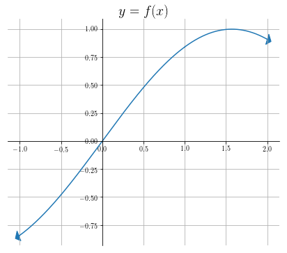

```python
#hideme

import math

def f(x):
    return np.sin(x)

def makeArrowY(ax,pos,function,direction):
    delta = 0.0001 if direction >= 0 else -0.01
    ax.arrow(pos,function(pos),delta,function(pos+delta)-function(pos),head_width=0.2,head_length=0.5, color="#1f77b4")

def makeArrowX(ax,pos,function,direction):
    delta = 0.0001 if direction >= 0 else -0.01
    ax.arrow(pos,function(pos),delta,function(pos+delta)-function(pos),head_width=0.1,head_length=0.05, color="#1f77b4")


fig = plt.figure(figsize=(7, 6))
ax = fig.add_subplot(111)
ax.set_title("$y = f(x)$", fontsize=20)

xleft = np.arange(-1, 1, 0.001)
xright = np.arange(1, 2, 0.001)
yright = f(xright)
yleft = f(xleft)
ax.plot(xleft, yleft)
ax.plot(xright, yright, color="#1f77b4")
#ax.yaxis.set_major_locator(ticker.MultipleLocator(1))

#ax.plot(1, 2, marker='o', linewidth=0, markersize=5, markerfacecolor="None",
         #markeredgecolor='black')


makeArrowX(ax, -1, f, -1)
makeArrowX(ax, 2, f, 1)


ax.grid(True)

ax.spines['left'].set_position('zero')
ax.spines['right'].set_color('none')
ax.spines['bottom'].set_position('zero')
ax.spines['top'].set_color('none')
ax.xaxis.set_ticks_position('bottom')
ax.yaxis.set_ticks_position('left')
```

## Limit Concept Questions

True or False: the approaching from the *left* is always the same as approaching from the *right*.

False! consider this example

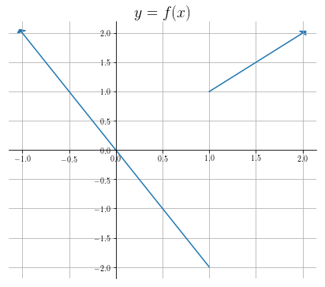

```python
#hideme

import math

def f(x):
    return x

def g(x):
    return -2*x

def makeArrowY(ax,pos,function,direction):
    delta = 0.0001 if direction >= 0 else -0.01
    ax.arrow(pos,function(pos),delta,function(pos+delta)-function(pos),head_width=0.2,head_length=0.5, color="#1f77b4")

def makeArrowX(ax,pos,function,direction):
    delta = 0.0001 if direction >= 0 else -0.01
    ax.arrow(pos,function(pos),delta,function(pos+delta)-function(pos),head_width=0.1,head_length=0.05, color="#1f77b4")


fig = plt.figure(figsize=(7, 6))
ax = fig.add_subplot(111)
ax.set_title("$y = f(x)$", fontsize=20)

xleft = np.arange(-1, 1, 0.001)
xright = np.arange(1, 2, 0.001)
yright = f(xright)
yleft = g(xleft)
ax.plot(xleft, yleft)
ax.plot(xright, yright, color="#1f77b4")
#ax.yaxis.set_major_locator(ticker.MultipleLocator(1))

#ax.plot(1, 2, marker='o', linewidth=0, markersize=5, markerfacecolor="None",
         #markeredgecolor='black')


makeArrowX(ax, -1, g, -1)
makeArrowX(ax, 2, f, 1)


ax.grid(True)

ax.spines['left'].set_position('zero')
ax.spines['right'].set_color('none')
ax.spines['bottom'].set_position('zero')
ax.spines['top'].set_color('none')
ax.xaxis.set_ticks_position('bottom')
ax.yaxis.set_ticks_position('left')
```

## Left and Right Limits

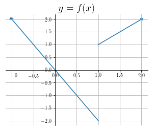

```python
#hideme

import math

def f(x):
    return x

def g(x):
    return -2*x

def makeArrowY(ax,pos,function,direction):
    delta = 0.0001 if direction >= 0 else -0.01
    ax.arrow(pos,function(pos),delta,function(pos+delta)-function(pos),head_width=0.2,head_length=0.5, color="#1f77b4")

def makeArrowX(ax,pos,function,direction):
    delta = 0.0001 if direction >= 0 else -0.01
    ax.arrow(pos,function(pos),delta,function(pos+delta)-function(pos),head_width=0.1,head_length=0.05, color="#1f77b4")


fig = plt.figure(figsize=(5, 4))
ax = fig.add_subplot(111)
ax.set_title("$y = f(x)$", fontsize=20)

xleft = np.arange(-1, 1, 0.001)
xright = np.arange(1, 2, 0.001)
yright = f(xright)
yleft = g(xleft)
ax.plot(xleft, yleft)
ax.plot(xright, yright, color="#1f77b4")
#ax.yaxis.set_major_locator(ticker.MultipleLocator(1))

#ax.plot(1, 2, marker='o', linewidth=0, markersize=5, markerfacecolor="None",
         #markeredgecolor='black')


makeArrowX(ax, -1, g, -1)
makeArrowX(ax, 2, f, 1)


ax.grid(True)

ax.spines['left'].set_position('zero')
ax.spines['right'].set_color('none')
ax.spines['bottom'].set_position('zero')
ax.spines['top'].set_color('none')
ax.xaxis.set_ticks_position('bottom')
ax.yaxis.set_ticks_position('left')
```

\begin{align} \underbrace{\lim_{x \rightarrow 1^-} f(x) = -2}_{\text{limit from the left}} && \underbrace{\lim_{x \rightarrow 1^+} f(x) = 1}_{\text{limit from the right}} \end{align}

But... if the left and right limits are not the same, then what is $\displaystyle\lim_{x \rightarrow 1} f(x)$ ???

## Evaluating a Limit

We are interested in calculating

\begin{equation} \lim_{x \rightarrow 1} \frac{(x^2 - 1)}{(x-1)} \end{equation}

The best way to evaluate a limit is to plug in value. We have seen $f(1) =$ undefined. So, what can we do?

\begin{align} &\lim_{x \rightarrow 1} \ \frac{(x+1)(x-1)}{(x-1)} \\ &\lim_{x \rightarrow 1} \ (x+1) = 2 \end{align}

🎉🎉🎉

## Quick Question

True or False: \begin{equation} \frac{(x^2 - 1)}{(x-1)} = (x+1) \end{equation}

Very very FALSE!! The two functions are the same everywhere *except when $x=1$*. This means the functions are **not** equal.

To go from $(x+1)$ to $\frac{(x^2 - 1)}{(x-1)}$, we need to divide by $(x-1)$, which is undefined for $x=1$. This is *not* the same as multiplying by any constant, which keeps things equal (i.e. $5 = 5\cdot \frac{2}{2}$).

## Let's practice!

The general method to evaluate a (finite) limit is to

1. Plug in the value. If it is defined, that is the limit!
2. Try to alter the function to something that is similar by multiplying, factoring, or other methods.
3. Re-evaluate the new function. If it is defined, that is the limit!

In *groups of 3*, evaluate the following limits

\begin{gather} \lim_{x \rightarrow 4} \ x^2 \\ \lim_{x \rightarrow 2} \ \frac{x^2 + 3x - 10}{(x-2)} \\ \lim_{x \rightarrow 4} \ \frac{2 - \sqrt{x}}{(4 - x)} \end{gather}

## Let's practice example 1

\begin{align} \lim_{x \rightarrow 4} \ x^2 \end{align}

This can be directly evaluated!

\begin{align} \lim_{x \rightarrow 4} \ x^2 = 4^2 = 16 \end{align}

## Let's practice example 2

\begin{align} \lim_{x \rightarrow 2} \ \frac{x^2 + 3x - 10}{(x-2)} \end{align}

Directly evaluating leads to $\frac{0}{0}$, which is undetermined.

We can factor!

\begin{align} \lim_{x \rightarrow 2} \ \frac{x^2 + 3x - 10}{(x-2)} &= \lim_{x \rightarrow 2} \ \frac{(x-2)(x+5)}{(x-2)} \\ &= \lim_{x \rightarrow 2} \ (x+5) \\ &= 7 \end{align}

## Let's practice example 3

\begin{align} \lim_{x \rightarrow 4} \ \frac{2 - \sqrt{x}}{(4 - x)} \end{align}

Directly evaluating leads to $\frac{0}{0}$, which is undetermined. We can multiply by the conjugate!

\begin{align} \lim_{x \rightarrow 4} \ \frac{(2 - \sqrt{x})}{(4 - x)} &= \lim_{x \rightarrow 4} \ \frac{(2 - \sqrt{x})}{(4 - x)} \cdot \frac{(2 + \sqrt{x})}{(2 + \sqrt{x})} \\ &= \lim_{x \rightarrow 4} \ \frac{(4 - x)}{(4 - x)(2 + \sqrt{x})} \\ &= \lim_{x \rightarrow 4} \ \frac{1}{(2 + \sqrt{x})} \\ &= \frac{1}{4} \end{align}

## Concept Questions

True or False: $\displaystyle\lim_{x \rightarrow 1} \ f(x) = 2$

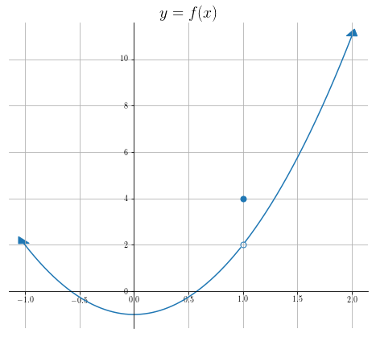

```python
#hideme

import math

def f(x):
    return (3*x**2 - 1)

def makeArrowY(ax,pos,function,direction):
    delta = 0.0001 if direction >= 0 else -0.01
    ax.arrow(pos,function(pos),delta,function(pos+delta)-function(pos),head_width=0.1,head_length=0.3, color="#1f77b4")

def makeArrowX(ax,pos,function,direction):
    delta = 0.0001 if direction >= 0 else -0.01
    ax.arrow(pos,function(pos),delta,function(pos+delta)-function(pos),head_width=0.1,head_length=0.05, color="#1f77b4")


fig = plt.figure(figsize=(8, 7))
ax = fig.add_subplot(111)
ax.set_title("$y = f(x)$", fontsize=20)

xleft = np.arange(-1, 0.98, 0.001)
xright = np.arange(1.02, 2, 0.001)
yright = f(xright)
yleft = f(xleft)
ax.plot(xleft, yleft)
ax.plot(xright, yright, color="#1f77b4")
#ax.yaxis.set_major_locator(ticker.MultipleLocator(1))

ax.plot(1, 2, marker='o', linewidth=0, markersize=7, markerfacecolor="none", markeredgecolor="#1f77b4")

ax.plot(1, 4, marker='o', linewidth=0, markersize=7,color="#1f77b4")


makeArrowY(ax, -1, f, -1)
makeArrowY(ax, 2, f, 1)


ax.grid(True)

ax.spines['left'].set_position('zero')
ax.spines['right'].set_color('none')
ax.spines['bottom'].set_position('zero')
ax.spines['top'].set_color('none')
ax.xaxis.set_ticks_position('bottom')
ax.yaxis.set_ticks_position('left')
```

## Concept Questions

True or False: $\displaystyle\lim_{x \rightarrow 1} \ f(x) = 2$

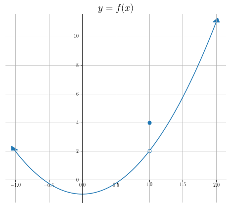

```python
#hideme

import math

def f(x):
    return (3*x**2 - 1)

def makeArrowY(ax,pos,function,direction):
    delta = 0.0001 if direction >= 0 else -0.01
    ax.arrow(pos,function(pos),delta,function(pos+delta)-function(pos),head_width=0.1,head_length=0.3, color="#1f77b4")

def makeArrowX(ax,pos,function,direction):
    delta = 0.0001 if direction >= 0 else -0.01
    ax.arrow(pos,function(pos),delta,function(pos+delta)-function(pos),head_width=0.1,head_length=0.05, color="#1f77b4")


fig = plt.figure(figsize=(8, 7))
ax = fig.add_subplot(111)
ax.set_title("$y = f(x)$", fontsize=20)

xleft = np.arange(-1, 0.98, 0.001)
xright = np.arange(1.02, 2, 0.001)
yright = f(xright)
yleft = f(xleft)
ax.plot(xleft, yleft)
ax.plot(xright, yright, color="#1f77b4")
#ax.yaxis.set_major_locator(ticker.MultipleLocator(1))

ax.plot(1, 2, marker='o', linewidth=0, markersize=7, markerfacecolor="none", markeredgecolor="#1f77b4")

ax.plot(1, 4, marker='o', linewidth=0, markersize=7,color="#1f77b4")


makeArrowY(ax, -1, f, -1)
makeArrowY(ax, 2, f, 1)


ax.grid(True)

ax.spines['left'].set_position('zero')
ax.spines['right'].set_color('none')
ax.spines['bottom'].set_position('zero')
ax.spines['top'].set_color('none')
ax.xaxis.set_ticks_position('bottom')
ax.yaxis.set_ticks_position('left')
```

## Review

If we are trying to evaluate $\displaystyle\lim_{x \rightarrow a} f(x)$

1. First evaluate $f(a)$
   - If it is defined and a real number, that is the limit (assuming the function is continuous)
2. If $f(a)$ is an indeterminate form, then try to rewrite the limit
   - Indeterminate forms include $\frac{0}{0}$, $\frac{\infty}{\infty}$, $0\cdot \infty$, $0^0$, $\infty^0$, $1^\infty$
     - Note that $\frac{1}{\infty}$ and $\infty$ are *not* indeterminate!
   - Rewrite by factoring, multplying by conjugate, or other more advanced methods
3. Lastly, if $f(a)$ is not defined but is not indeterminate, then $a$ is probably a special value called an *asymptote*. We will learn more about this case next lesson! 😊